# Visualisation of WLTC cycles

### VISUALISATION OF WLTC CYCLES

**Worldwide harmonized Light vehicles Test Procedures (WLTP)** consists of tests to measure fuel consumption, CO2 emission, pollutant emission and energy consumption values of alternative power trains.

The old lab test – called the New European Driving Cycle (NEDC) – was designed in the 1980s. While the NEDC test determined test values based on a theoretical driving profile, the WLTP cycle was developed using real-driving data, gathered from around the world. WLTP therefore better represents everyday driving profiles. It was developed with the aim of being used as a global test cycle across different world regions, so pollutant and CO2 emissions as well as fuel consumption values would be comparable worldwide.

The WLTP driving cycle - **The Worldwide harmonized Light vehicles Test Cycles (WLTC)** are chassis dynamometer tests for the determination of emissions and fuel consumption from light-duty vehicles. It is divided into four parts with different average speeds: low, medium, high and extra high. Each part contains a variety of driving phases, stops, acceleration and braking phases. For a certain car type, each powertrain configuration is tested with WLTP for the car’s lightest (most economical) and heaviest (least economical) version.

The WLTC cycles vary based on vehicle categories of different power-to-mass (PMR) ratio. PMR is defined as the ratio of rated power (W) / curb mass (kg).

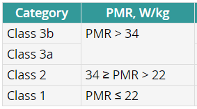

Using data I found on the UNECE website (https://unece.org/), I have plotted the **Speed vs. Time** and **Acceleration vs. Time** graphs for the **Class1 and Class 2** cycles below.

### WLTC CLASS 1

Importing necessary libraries

```python
import pandas as pd
import numpy as np
import matplotlib.pyplot as plt
```

Reading WLTC class 1 csv into a pandas dataframe

```python
class1_dataset = pd.read_csv(r"C:\Users\Raveendra\Desktop\WLTC\class1_WLTC.csv")
c1 = class1_dataset.copy(deep=True)
```

Getting an overview of the dataframe

```python
print(c1.info())
```

```
<class 'pandas.core.frame.DataFrame'>
RangeIndex: 1023 entries, 0 to 1022
Data columns (total 5 columns):
 #   Column                                    Non-Null Count  Dtype
---  ------                                    --------------  -----
 0   Phase                                     1023 non-null   object
 1   Total elapsed time                        1023 non-null   int64
 2   Phase elapsed time                        1023 non-null   int64
 3   WLTC class 1, version 1.4, vehicle speed  1023 non-null   float64
 4   WLTC class 1, version 1.4, acceleration   1023 non-null   float64
dtypes: float64(2), int64(2), object(1)
memory usage: 40.1+ KB
None
```

making Time, speed and acceleration vectors from dataframe

```python
time1 = c1['Total elapsed time']
speed1 = c1['WLTC class 1, version 1.4, vehicle speed']
acc1 = c1['WLTC class 1, version 1.4, acceleration']
```

Finding the partiton between Low and Medium Phases.

```python
phase_changes = c1["Phase"].shift() != c1["Phase"]
phase_changes.iloc[0]=False
partition = c1[phase_changes].index
```

Plotting Speed vs Time in p1 and plotting Acceleration vs Time in p2

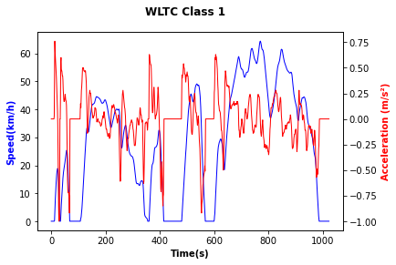

```python
time1 = c1['Total elapsed time']
speed1 = c1['WLTC class 1, version 1.4, vehicle speed']
acc1 = c1['WLTC class 1, version 1.4, acceleration']
my_column_changes = c1["Phase"].shift() != c1["Phase"]
my_column_changes.iloc[0]=False
partition = c1[my_column_changes].index
fig, p1 = plt.subplots()
fig.suptitle("WLTC Class 1",weight='bold')
p1.set_xlabel("Time(s)",weight='bold')
p1.set_ylabel("Speed(km/h)", color='blue',weight='bold')
p1.plot(time1, speed1, color='blue', linewidth=1)
p2 = p1.twinx()
p2.plot(time1, acc1, color='red', linewidth=1)
p2.set_ylabel("Acceleration (m/s²)", color='red',weight='bold')


plt.show()
```

Drawing the partition lines between phases

[figure not shown]

```python
plt.axvline(partition, color='black', linestyle='--', linewidth=3)
p1.text(200, 5, 'Low',weight='bold')
p1.text(800, 5, 'Medium',weight='bold')
```

**FINAL WLTC Class1 plot**

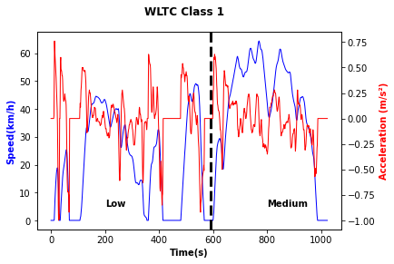

```python
time1 = c1['Total elapsed time']
speed1 = c1['WLTC class 1, version 1.4, vehicle speed']
acc1 = c1['WLTC class 1, version 1.4, acceleration']
my_column_changes = c1["Phase"].shift() != c1["Phase"]
my_column_changes.iloc[0]=False
partition = c1[my_column_changes].index
fig, p1 = plt.subplots()
fig.suptitle("WLTC Class 1",weight='bold')
p1.set_xlabel("Time(s)",weight='bold')
p1.set_ylabel("Speed(km/h)", color='blue',weight='bold')
p1.plot(time1, speed1, color='blue', linewidth=1)
p2 = p1.twinx()
p2.plot(time1, acc1, color='red', linewidth=1)
p2.set_ylabel("Acceleration (m/s²)", color='red',weight='bold')

plt.axvline(partition, color='black', linestyle='--', linewidth=3)
p1.text(200, 5, 'Low',weight='bold')
p1.text(800, 5, 'Medium',weight='bold')


plt.show()
```

### WLTC CLASS 2 PLOTS

Reading WLTC Class 2 csv into pandas dataframe

```python
c2=pd.read_csv(r"C:\Users\Raveendra\Desktop\WLTC\class2_WLTC.csv")
print(c2.info())
```

```
<class 'pandas.core.frame.DataFrame'>
RangeIndex: 1478 entries, 0 to 1477
Data columns (total 6 columns):
 #   Column                                    Non-Null Count  Dtype
---  ------                                    --------------  -----
 0   Phase                                     1478 non-null   object
 1   Total elapsed time                        1478 non-null   int64
 2   Phase elapsed time                        1478 non-null   int64
 3   WLTC class 2, version 1.4, vehicle speed  1478 non-null   float64
 4   WLTC class 2, version 1.4, acceleration   1478 non-null   float64
 5   Unnamed: 5                                0 non-null      float64
dtypes: float64(3), int64(2), object(1)
memory usage: 69.4+ KB
None
```

Making Time, Speed and Acceleration vectors from dataframe

```python
time2=c2['Total elapsed time']
speed2=c2['WLTC class 2, version 1.4, vehicle speed']
acc2=c2['WLTC class 2, version 1.4, acceleration']
```

Finding the partiton between Low, Medium and High

```python
phase_changes = c2["Phase"].shift() != c2["Phase"]
phase_changes.iloc[0]=False
partitions = c2[phase_changes].index
print(partitions)
```

```
Int64Index([590, 1023], dtype='int64')
```

Creating the plots

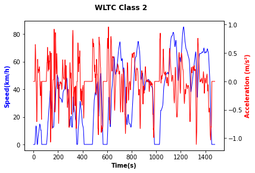

```python
fig, p3 = plt.subplots()
fig.suptitle("WLTC Class 2",weight='bold')
p3.set_xlabel("Time(s)",weight='bold')
p3.set_ylabel("Speed(km/h)", color='blue',weight='bold')
p3.plot(time2, speed2,color='blue', linewidth=1)
p4 = p3.twinx()
p4.plot(time2,acc2,color='red', linewidth=1)
p4.set_ylabel("Acceleration (m/s²)", color='red',weight='bold')
```

Drawing the partitions between phases

[figure not shown]

```python
for part in partitions:
    plt.axvline(part, color='black', linestyle='--', linewidth=3)
```

**FINAL WLTC Class2 plot**

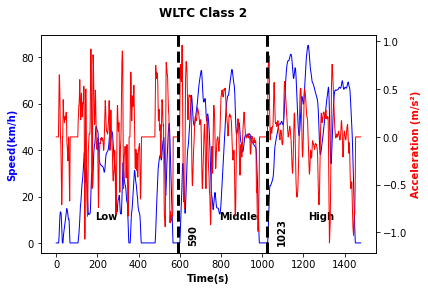

```python
fig, p3 = plt.subplots()
fig.suptitle("WLTC Class 2",weight='bold')
p3.set_xlabel("Time(s)",weight='bold')
p3.set_ylabel("Speed(km/h)", color='blue',weight='bold')
p3.plot(time2, speed2, color='blue', linewidth=1)
p4 = p3.twinx()
p4.plot(time2, acc2, color='red', linewidth=1)
p4.set_ylabel("Acceleration (m/s²)", color='red',weight='bold')
p3.text((partition[0]-400),10,c2.at[1,'Phase'],weight='bold')#low label positioning
for part in partitions:
    plt.axvline(part, color='black', linestyle='--', linewidth=3)
    p3.text((part+50),0,part,rotation=90,weight='bold')#partition line time value label
    p3.text((part+200),10,c2.at[part,'Phase'],weight='bold')#medium and high label positioning
```